# econ2200Ch04 slides

[figure not shown]

## ECON2200H

### Introduction to Statistics for Economics and Management

### 2020 Winter Term

### Week 03: Introduction to Probability Theory (revised)

#### 20 January 2020

## Outline

Basic theory of probability, corresponding to Chapter 4 of textbook

- Experiment, outcome, event
- Axioms of probability
- How to count
- Conditional probability
- Independence
- Contingency table, tree diagram.

## 1. Basic concepts

- Probability is defined on events. We need to know what an event is.

### 1-1. Sample space and events

- An **experiment** is an activity or procedure that produces *distinct* well-defined possible outcomes that can be identified ahead of time.
- An **outcome** is one particular result of an experiment.
- The **sample space** is the collection of all possible outcomes of an experiment.
- An **event** is a well-defined *set* of possible outcomes of the experiment.
- Thus, an event is a *subset* of the sample space.

#### Example: Rolling a Die

- Experiment: roll a die
- All possible outcomes: 1,2,3,4,5,6
- Sample space: $S$ = {1,2,3,4,5,6}
- Event: observe the number 4, which is {4}
- Event: observe a number that is greater than 4, which is {5,6}
- Event: an even number is obtained, which is {2, 4, 6}

#### Example: Tossing a coin twice

- Experiment: Toss a coin twice
- Possible outcomes: HH, HT, TH, TT. The first letter is the outcome of a first toss, the second letter is the outcome of a second toss.
- Sample space: $S$ = {HH, HT, TH, TT}
- Event: the first toss is heads = {HH, HT}
- Event: two tosses have the same side = {HH, TT}
- The **union** of event A and event B is the event C that either A occurs or B occurs or both occur: C = A$\cup$B,
  - i.e., the set of outcomes that are in A only, in B only, or in both A and B.
- The **intersection** of event A and event B is the event C that both A and B occur: C = A$\cap$B.
  - i.e., the set of outcomes that are both in A and in B.
- Event A and event B are said to be **disjoint** if A$\cap$B = {$\emptyset$} which is an empty set,
  - i.e., there is no outcome that is in both A and B.
  - In textbook, it's called that A and B are **mutually exclusive**.
- The **complement** of an event A is the event that A does not occur. Thus, the complement of A consists of outcomes in the sample space that are not in A.

#### Example: Tossing a coin twice.

- Sample space is $S$ = {HH, HT, TH, TT}.
- Let event A = the first toss is heads, A = {HH, HT}.
- Let event B = two tosses have the same side, B = {HH, TT}.
- The union of A and B is A$\cup$B = {HH,HT,TT}.
- The intersection of A and B is A$\cap$B = {HH}.
- The complement of A is {TH, TT}.
- Venn diagrams for union and intersection

[figure not shown]

### 1-2. Basic probability theory

  (2). $P(S)=1$, i.e. the probability of sample space $S$ is one.

  (3). If event $A$ and event $B$ are disjoint, then $P(A\cup B) = P(A) + P(B)$.

#### Basic properties of probability

- Let event $A^c$ be the complement of event $A$, then $P(A^c) = 1 - P(A)$.
  - Equivalently, $P(A) + P(A^c) =1$.
- $P(A\cup B) = P(A) + P(B) - P(A\cap B)$.
  - Intuitively, $P(A)+P(B)$ counts $P(A \cap B)$ twice, so must subtract $P(A \cap B)$.
- Refer to Venn diagrams for both properties.
- Obviously, if A and B are disjoint, $P(A\cap B) = 0$.

#### Example. Tossing a coin twice

- Sample space is $S$ = {HH, HT, TH, TT}.
- We assume that each elementary outcome in $S$ is equally likely and has probability $\frac{1}{4}$.
- Let A denote the event of heads on the first toss, A = {HH, HT}.
- Let B denote the event of two tosses having the same side, B = {HH, TT}.
- Then $P(A) = \frac{1}{4} + \frac{1}{4} = \frac{1}{2}$.
- Why? Event {HH} and event {HT} are disjoint because elementary outcomes are distinct. Then by axiom (3), $P(A)= P(\{\text{HH}\}) + P(\{\text{HT}\}) = \frac{1}{2}$.
- $P(B) = \frac{1}{2}$.
- $P(A \cap B) = \frac{1}{4}$, since $P(A\cap B)=$ probability of {HH}.
- $P(A\cup B) = P(A) + P(B) - P(A\cap B) = \frac{1}{2} + \frac{1}{2} - \frac{1}{4} = \frac{3}{4}$.
  - Indeed, A$\cup$B = {HH,HT,TT}, its probably is 3/4.

#### Example. Rolling a die

- Assume that each side facing up is equally likely.
- Let event A be obtaining a number that less than 3, then $P(A) = \frac{2}{6}$.

### 1-3. Interpretations of probability

- There are three common operational interpretations of probability.
  - The frequency interpretation.
  - The classical interpretation.
  - The subjective interpretation.
- Fortunately, the probability calculations apply equally well no matter which interpretation one uses.
- The theory of probability does not depend on how one interprets probability.

#### The frequency interpretation of probability

- The probability of an outcome can be interpreted as the *relative frequency* with which that outcome would be obtained if the process is repeated a large number of times under similar conditions.
- **Example**. The probability of obtaining a head when tossing a coin is considered to be 1/2, because the relative frequency of heads should be approximately 1/2 when the coin is tossed many times.
- But this is interpretation is too vague to serve as a scientific definition of probability, because

  1). A "large number" of tosses of the coin does not tell a definite actual number that would be considered as large.

  2). The coin should be tossed "under similar conditions", it is imprecise.
- Moreover, the frequency interpretation cannot be applied to many important problems,
  - because repeated trials are impossible.
  - For example, the probability of an R&D project leading to a new commercialized product within a year.

#### The classical interpretation of probability

- The classical interpretation relies on the assumption of *equally liekly outcomes*.
- Two possible outcomes in coin tossing: a head or a tail.
- We may want to assume that the two outcomes are equally likely to occur, they have the same probability.
- The problem with this interpretation is that in some cases outcomes are not equally likely.
- Example: the probability of an R&D project leading to a new commercialized product within a year may not be half (success) and half (failure).

#### The subjective interpretation of probability

- Probability that a person assigns to a possible outcome depends on the person's judgement.of the likelihood.
  - It is called *subjective probability*.
- Personal judgment is based on the person's beliefs and the person's information about the process.
- Example: the probability of an R&D project leading to a new commercialized product within a year may differ by people,
  - the R&D manager.
  - the R&D engineer.
  - the marketing manager.

## 2. How to count

### 2-1. The Multiplication rule

- **If one experiment has $m$ outcomes and another has $n$ outcomes, then there are $m\cdot n$ possible outcomes for the two experiments**.
- **Example**. Rolling two dice, one is red, the other green. Six possible outcomes for each die.
- The number of possible outcomes for the experiment is $6 \cdot 6 = 36$.

[figure not shown]

### 2-2. Combinations.

- **Combination**. Take $k$ objects from a set of $n$ objects without replacement and disregarding the order of elements in $k$ objects.
- Example. Take 3 cards of different colors from a set of 5 cards of different colors, without replacement and disregarding the order.
  - (Red, Green, Blue), (Red, Blue, Green), (Blue, Red, Green), (Blue, Green, Red), (Green, Red, Blue), and (Green, Blue, Red) are the same combination, but different permutations.
- How many combinations of 3 cards taken from 5 cards of different colors are there?
- Start with permutation, The number permutations of 3 cards from 5 cards is $\frac{5!}{(5-3)!} = 60$.
- For each group of 3 colors, we have $3!=6$ permutations, but one combination.
- Thus, the number of combinations of 3 cards taken from a set of 5 cards is $$\frac{60}{6} = 10 = \frac{5!}{ 3!(5-3)!}.$$
- The **combination formula**: the number of combinations of $k$ objects taken from a set of $n$ objects (without replacement) is given by

$$C_{n,k} = \frac{n!}{k! (n-k)!}.$$

- We often write $C_{n,k}$ as $\binom{n}{k}$. The textbook writes $_nC_k$ for $C_{n,k}$.
- Combination formula suggests that $C_{n,k} = C_{n,n-k}$, equivalently, $\binom{n}{k} = \binom{n}{n-k}$.
- Example. LOTTO 6/49. Choose 6 numbers from 1 to 49. The number of possible combinations of taking 6 numbers from 49 numbers (without replacement) is $$\binom{49}{6} = \frac{49!}{6! (49-6)!} = 13,983,816.$$
- The probability of "Jackpot win or Share of 80.5% of the Pool's Fund" (6-number matching) is 1 in 14 million.
- The number $\binom{n}{k}$ is also called the binomial coefficient, due to the theorem below.
- FYI: **Binomial Theorem**. For all numbers $x$ and $y$, and each positive integer $n$, $$(x+y)^n = \sum_{k=0}^n \binom{n}{k} x^k y^{n-k}.$$
- $\binom{n}{0} = 1$, for that we assume that $0!=1$.
- If $x=1$ and $y=1$, then $2^n = \sum_{k=0}^n \binom{n}{k}$. This can be interpreted as the number of subsets of a set of $n$ objects, where the empty set is considered a subset.

## 3. Conditional Probability and Independence

- Suppose that the event A with $P(A)>0$ occurs. the **conditional probability** of event B given event A is defined as $$P(B|A) = \frac{P(A\cap B)}{P(A)}.$$
- In words, the probability of B given A is the probability of the intersection of A and B divided by the probability of A.
- The idea behind it: if event A is given, the relevant sample space is reduced to A from original sample space $S$.
- **Multiplication Rule for conditional probabilities**: $P(A\cap B) = P(B|A) \cdot P(A)$.

#### Example. Roll two dice.

- Let A = "the sum is 8" and B = "the first die observes 3".
- Sample space is the set consisting of 36 permutations, as shown in Section 2-1 above.
- Then, A = {(2,6),(6,2),(3,5),(5,3),(4,4)}; B = {(3,1),(3,2),(3,3),(3,4),(3,5),(3,6)}; A$\cap$B = {(3,5)}.
- $P(A) = 5/36$, $P(A\cap B) = 1/36$. Then $P(B|A) = \frac{1/36}{5/36} = \frac{1}{5}$.
- Why? We want to find probability of event B, after event A has occurred. Then, in A we look for outcomes with 3 as the first number. One outcome in A falls in B: (3,5). Then $P(B|A) = 1/5$.

#### Example. LOTTO 6/49

- The sample space S consists of the 13,983,816 possible combinations of 6 numbers from 49 numbers,
  - recall, $\binom{49}{6} = \frac{49!}{6! (49-6)!}=13,983,816$.
- Suppose I learned that the event A = {4 is one of the six numbers in the winning play} has occurred.
- The event B = {my ticket wins}.
- The event A consists of combinations of numbers that include 4, then $$P(A) = \frac{\binom{48}{5}}{\binom{49}{6}} = \frac{6}{49}=0.1225.$$
- The event B consists of a single outcome that is also in A, so A$\cap$ B =B. Thus once A occurs, the sample space reduces to A from S.
- Then, $P(A\cap B) = P(B) = \frac{1}{\binom{49}{6}} = \frac{1}{13,983,816}$.
- The conditional probability of B given A is $$P(B|A) = \frac{ 1/\binom{49}{6}}{6/49} = \frac{49/6}{13,983,816}.$$
- Therefore, knowing one number being 4 increases the probability of winning by a factor of 8 ($\approx$ 49/6).

#### (Optional). Total probability, Bayes' rule.

1. Law of total probability.

Let $A_1,A_2,\cdots, A_m$ be disjoint partitions of sample space $S$, that is $A_1\cup A_2 \cup \cdots \cup A_m=S$ and $A_i \cap A_j = \emptyset$ for $i \ne j$. Further, $P(A_i)>0$ for all $i$. Then, for any event B, $$P(B) = \sum_{i=1}^m P(B|A_i) \cdot P(A_i).$$

1. Bayes' rule.

Let $A_1,A_2,\cdots, A_m$ be disjoint partitions of sample space $S$, that is $A_1\cup A_2 \cup \cdots \cup A_m=S$ and $A_i \cap A_j = \emptyset$ for $i \ne j$. Further, $P(A_i)>0$ for all $i$. Let $B$ be an event. Then $$P(A_j|B) = \frac{P(B|A_j) \cdot P(A_j)}{\sum_{i=1}^m P(B|A_i) \cdot P(A_i)}.$$

Example: Let $m=2$ , then $P(A_1|B) = \frac{P(B|A_1) \cdot P(A_1)}{P(B|A_1) \cdot P(A_1)+P(B|A_2) \cdot P(A_2)}$.

### Independence

- Two events $A$ and $B$ are said to be **independent** if $P(A\cap B) = P(A)\cdot P(B)$.
- By the definition of conditional probability, then $P(B|A) = P(B)$ if and only if A and B are independent.
- **Two events being independent does not imply that they are disjoint**.
- Recall, event A and event B are disjoint if $A\cap B = \{\emptyset\}$, then $P(A \cap B) = 0$.
- **Example**. Rolling a die. Let $A$ be the event that an even number is obtained, and let $B$ be the event that a number less than 5 is obtained.
- Then $P(A) = 3/6 = 1/2$, and $P(B) = 4/6 = 2/3$. Because $A \cap B$ = {2,4}, $P(A\cap B) = 2/6 = 1/3$.
- Events A and B are independent since $P(A\cap B) = P(A) \cdot P(B)$.
- Alternatively, $P(B|A) = \frac{P(A\cap B)}{P(A)} = \frac{1/3}{1/2} = \frac{2}{3} = P(B)$, independence.
- But event A and event B are *not* disjoint, since $A\cap B = \{2,4\}$.

## 4. Contingency tables and Tree Diagrams

- A **contingency table** is a table used to classify sample observations according to two or more identifiable characteristics.
- Example. A sample of consumer availing telecom services was surveyed. One of the questions was, "If you were given an offer by another service provider with more talk time and less charges, would you continue with the same service provider or go with new one?" The responses of the 160 consumers in the survey were cross-tabulated with their duration of availing service with the current service provider.

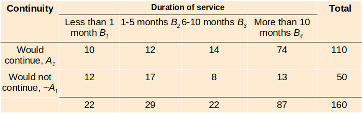

- What is the probability of randomly selecting a consumer who would continue and who is availing more than 10 months of service?
  - $P(A_1 \cap B_4) = P(A_1) \cdot P(B_4|A_1) = \frac{110}{160} \cdot \frac{74}{110} = 0.463$.
- What is the probability of randomly selecting a consumer who would continue or is availing less than one month of service?
  - $P(A_1 \cup B_1) = P(A_1) + P(B_1) - P(A_1\cap B_1) = 0.69 + 0.14 - 0.06 = 0.77$.
- A **tree diagram** is a graph that organizes calculations involving several stages.

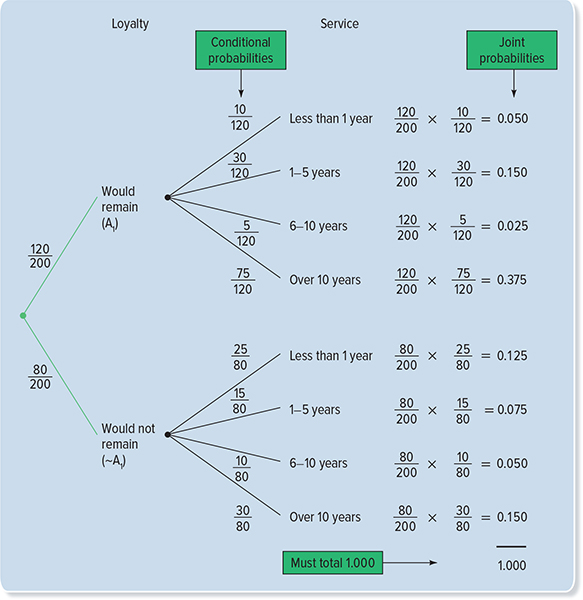